# Data Imputation & Classification

### This project is based on the [Automobile Dataset](https://www.kaggle.com/toramky/automobile-dataset) from Kaggle. The two objectives of this project is:

### Data Imputation of missing data Determination of best classification algorithm using K-Cross validation method

```python
import matplotlib.pyplot as plt
import numpy as np
import pandas as pd
import seaborn as sns

from IPython.display import Markdown as md
```

```python
from plotly.offline import download_plotlyjs, init_notebook_mode, plot, iplot
import plotly.graph_objects as go
import plotly.express as px
import cufflinks as cf

init_notebook_mode(connected=True)
cf.go_offline()
```

```python
automobile_df = pd.read_csv('Automobile_data.csv')
automobile_df.head(10)
```

|  | symboling | normalized-losses | make | fuel-type | aspiration | num-of-doors | body-style | drive-wheels | engine-location | wheel-base | ... | engine-size | fuel-system | bore | stroke | compression-ratio | horsepower | peak-rpm | city-mpg | highway-mpg | price |
| --- | --- | --- | --- | --- | --- | --- | --- | --- | --- | --- | --- | --- | --- | --- | --- | --- | --- | --- | --- | --- | --- |
| 0 | 3 | ? | alfa-romero | gas | std | two | convertible | rwd | front | 88.6 | ... | 130 | mpfi | 3.47 | 2.68 | 9.0 | 111 | 5000 | 21 | 27 | 13495 |
| 1 | 3 | ? | alfa-romero | gas | std | two | convertible | rwd | front | 88.6 | ... | 130 | mpfi | 3.47 | 2.68 | 9.0 | 111 | 5000 | 21 | 27 | 16500 |
| 2 | 1 | ? | alfa-romero | gas | std | two | hatchback | rwd | front | 94.5 | ... | 152 | mpfi | 2.68 | 3.47 | 9.0 | 154 | 5000 | 19 | 26 | 16500 |
| 3 | 2 | 164 | audi | gas | std | four | sedan | fwd | front | 99.8 | ... | 109 | mpfi | 3.19 | 3.4 | 10.0 | 102 | 5500 | 24 | 30 | 13950 |
| 4 | 2 | 164 | audi | gas | std | four | sedan | 4wd | front | 99.4 | ... | 136 | mpfi | 3.19 | 3.4 | 8.0 | 115 | 5500 | 18 | 22 | 17450 |
| 5 | 2 | ? | audi | gas | std | two | sedan | fwd | front | 99.8 | ... | 136 | mpfi | 3.19 | 3.4 | 8.5 | 110 | 5500 | 19 | 25 | 15250 |
| 6 | 1 | 158 | audi | gas | std | four | sedan | fwd | front | 105.8 | ... | 136 | mpfi | 3.19 | 3.4 | 8.5 | 110 | 5500 | 19 | 25 | 17710 |
| 7 | 1 | ? | audi | gas | std | four | wagon | fwd | front | 105.8 | ... | 136 | mpfi | 3.19 | 3.4 | 8.5 | 110 | 5500 | 19 | 25 | 18920 |
| 8 | 1 | 158 | audi | gas | turbo | four | sedan | fwd | front | 105.8 | ... | 131 | mpfi | 3.13 | 3.4 | 8.3 | 140 | 5500 | 17 | 20 | 23875 |
| 9 | 0 | ? | audi | gas | turbo | two | hatchback | 4wd | front | 99.5 | ... | 131 | mpfi | 3.13 | 3.4 | 7.0 | 160 | 5500 | 16 | 22 | ? |

10 rows × 26 columns

## Data Conversion and Imputation

#### This dataset represents null value with '?'

#### To start of, let's first replace them with NaN

```python
automobile_df.replace('?', np.NaN, inplace=True)
```

```python
automobile_df.info()
```

```
<class 'pandas.core.frame.DataFrame'>
RangeIndex: 205 entries, 0 to 204
Data columns (total 26 columns):
 #   Column             Non-Null Count  Dtype
---  ------             --------------  -----
 0   symboling          205 non-null    int64
 1   normalized-losses  164 non-null    object
 2   make               205 non-null    object
 3   fuel-type          205 non-null    object
 4   aspiration         205 non-null    object
 5   num-of-doors       203 non-null    object
 6   body-style         205 non-null    object
 7   drive-wheels       205 non-null    object
 8   engine-location    205 non-null    object
 9   wheel-base         205 non-null    float64
```

[output cut: 18 more lines]

#### Converting some of the object type features to float64

```python
obj_col_list = ['normalized-losses', 'bore', 'stroke', 'horsepower', 'peak-rpm', 'price']

for col in obj_col_list:
    automobile_df[col] = automobile_df[col].astype('float64')
```

```python
automobile_df.info()
```

```
<class 'pandas.core.frame.DataFrame'>
RangeIndex: 205 entries, 0 to 204
Data columns (total 26 columns):
 #   Column             Non-Null Count  Dtype
---  ------             --------------  -----
 0   symboling          205 non-null    int64
 1   normalized-losses  164 non-null    float64
 2   make               205 non-null    object
 3   fuel-type          205 non-null    object
 4   aspiration         205 non-null    object
 5   num-of-doors       203 non-null    object
 6   body-style         205 non-null    object
 7   drive-wheels       205 non-null    object
 8   engine-location    205 non-null    object
 9   wheel-base         205 non-null    float64
```

[output cut: 18 more lines]

#### A heatmap to see the extent of missing data

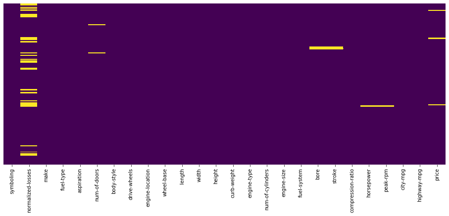

```python
fig, ax = plt.subplots(figsize=(16,6))
sns.heatmap(automobile_df.isnull(),yticklabels=False,cbar=False,cmap='viridis')
```

#### Features with NaN:

```python
automobile_df.columns[automobile_df.isnull().any()].tolist()
```

```
['normalized-losses',
 'num-of-doors',
 'bore',
 'stroke',
 'horsepower',
 'peak-rpm',
 'price']
```

### I will go through the features by one and try to do imputation more accurately based on trend or correlation

### If no strong correlation is found, then I will fill the missing blanks with mean or mode

### normalized-losses

```python
automobile_df['normalized-losses'] = automobile_df['normalized-losses'].dropna()
```

```python
automobile_df['normalized-losses'].mean()
```

```
122.0
```

```python
automobile_df['normalized-losses'].mode()
```

```
0    161.0
dtype: float64
```

```python
automobile_df['normalized-losses'].median()
```

```
115.0
```

```python
# This function shows correlation value of selected feature with ALL the features
def show_correlation(sel_feature):
    corr_list = automobile_df[list(automobile_df.columns)].corr()[sel_feature]
    return corr_list.sort_values(ascending=False)
```

```python
corr_list = show_correlation('normalized-losses')
corr_list
```

```
normalized-losses    1.000000
symboling            0.528667
horsepower           0.295772
peak-rpm             0.264597
price                0.203254
engine-size          0.167365
curb-weight          0.119893
width                0.105073
stroke               0.065627
length               0.023220
bore                -0.036167
wheel-base          -0.074362
compression-ratio   -0.132654
highway-mpg         -0.210768
city-mpg            -0.258502
height              -0.432335
Name: normalized-losses, dtype: float64
```

#### No strong correlation of normalized-losses with other features so I'll just fill NaN with the mean

```python
automobile_df['normalized-losses'].fillna(automobile_df['normalized-losses'].mean(), inplace=True)
```

### num-of-doors

```python
automobile_df[automobile_df['num-of-doors'].isnull()]
```

|  | symboling | normalized-losses | make | fuel-type | aspiration | num-of-doors | body-style | drive-wheels | engine-location | wheel-base | ... | engine-size | fuel-system | bore | stroke | compression-ratio | horsepower | peak-rpm | city-mpg | highway-mpg | price |
| --- | --- | --- | --- | --- | --- | --- | --- | --- | --- | --- | --- | --- | --- | --- | --- | --- | --- | --- | --- | --- | --- |
| 27 | 1 | 148.0 | dodge | gas | turbo | NaN | sedan | fwd | front | 93.7 | ... | 98 | mpfi | 3.03 | 3.39 | 7.6 | 102.0 | 5500.0 | 24 | 30 | 8558.0 |
| 63 | 0 | 122.0 | mazda | diesel | std | NaN | sedan | fwd | front | 98.8 | ... | 122 | idi | 3.39 | 3.39 | 22.7 | 64.0 | 4650.0 | 36 | 42 | 10795.0 |

2 rows × 26 columns

#### Since sedans are four-door cars

```python
automobile_df['num-of-doors'].fillna('four', inplace=True)
```

#### Now I will convert the string to integers

```python
num_door_list = automobile_df['num-of-doors'].unique()
```

```python
num_dict = {'one': 1, 'two': 2, 'three': 3, 'four': 4, 'five': 5,
            'six': 6, 'seven': 7, 'eight': 8, 'nine':9, 'ten':10, 'eleven': 11,
            'twelve': 12}
num_dict
```

```
{'one': 1,
 'two': 2,
 'three': 3,
 'four': 4,
 'five': 5,
 'six': 6,
 'seven': 7,
 'eight': 8,
 'nine': 9,
 'ten': 10,
 'eleven': 11,
 'twelve': 12}
```

```python
def covert_str_to_num(num_list, df, col_name):
    for num in num_list:
        if type(num) is int or type(num) is float:
            pass
        else:
            df.loc[df[col_name] == num, col_name] = num_dict[num]
    df[col_name] = df[col_name].astype('float64')
    return df
```

```python
automobile_df = covert_str_to_num(num_list=num_door_list, df=automobile_df, col_name='num-of-doors')
automobile_df.head(10)
```

|  | symboling | normalized-losses | make | fuel-type | aspiration | num-of-doors | body-style | drive-wheels | engine-location | wheel-base | ... | engine-size | fuel-system | bore | stroke | compression-ratio | horsepower | peak-rpm | city-mpg | highway-mpg | price |
| --- | --- | --- | --- | --- | --- | --- | --- | --- | --- | --- | --- | --- | --- | --- | --- | --- | --- | --- | --- | --- | --- |
| 0 | 3 | 122.0 | alfa-romero | gas | std | 2.0 | convertible | rwd | front | 88.6 | ... | 130 | mpfi | 3.47 | 2.68 | 9.0 | 111.0 | 5000.0 | 21 | 27 | 13495.0 |
| 1 | 3 | 122.0 | alfa-romero | gas | std | 2.0 | convertible | rwd | front | 88.6 | ... | 130 | mpfi | 3.47 | 2.68 | 9.0 | 111.0 | 5000.0 | 21 | 27 | 16500.0 |
| 2 | 1 | 122.0 | alfa-romero | gas | std | 2.0 | hatchback | rwd | front | 94.5 | ... | 152 | mpfi | 2.68 | 3.47 | 9.0 | 154.0 | 5000.0 | 19 | 26 | 16500.0 |
| 3 | 2 | 164.0 | audi | gas | std | 4.0 | sedan | fwd | front | 99.8 | ... | 109 | mpfi | 3.19 | 3.40 | 10.0 | 102.0 | 5500.0 | 24 | 30 | 13950.0 |
| 4 | 2 | 164.0 | audi | gas | std | 4.0 | sedan | 4wd | front | 99.4 | ... | 136 | mpfi | 3.19 | 3.40 | 8.0 | 115.0 | 5500.0 | 18 | 22 | 17450.0 |
| 5 | 2 | 122.0 | audi | gas | std | 2.0 | sedan | fwd | front | 99.8 | ... | 136 | mpfi | 3.19 | 3.40 | 8.5 | 110.0 | 5500.0 | 19 | 25 | 15250.0 |
| 6 | 1 | 158.0 | audi | gas | std | 4.0 | sedan | fwd | front | 105.8 | ... | 136 | mpfi | 3.19 | 3.40 | 8.5 | 110.0 | 5500.0 | 19 | 25 | 17710.0 |
| 7 | 1 | 122.0 | audi | gas | std | 4.0 | wagon | fwd | front | 105.8 | ... | 136 | mpfi | 3.19 | 3.40 | 8.5 | 110.0 | 5500.0 | 19 | 25 | 18920.0 |
| 8 | 1 | 158.0 | audi | gas | turbo | 4.0 | sedan | fwd | front | 105.8 | ... | 131 | mpfi | 3.13 | 3.40 | 8.3 | 140.0 | 5500.0 | 17 | 20 | 23875.0 |
| 9 | 0 | 122.0 | audi | gas | turbo | 2.0 | hatchback | 4wd | front | 99.5 | ... | 131 | mpfi | 3.13 | 3.40 | 7.0 | 160.0 | 5500.0 | 16 | 22 | NaN |

10 rows × 26 columns

### num-of-cylinders

#### No data missing here but I'm going to convert string to integers

```python
num_cyl_list = automobile_df['num-of-cylinders'].unique()
num_cyl_list
```

```
array(['four', 'six', 'five', 'three', 'twelve', 'two', 'eight'],
      dtype=object)
```

```python
automobile_df = covert_str_to_num(num_list=num_cyl_list, df=automobile_df, col_name='num-of-cylinders')
automobile_df['num-of-cylinders']
```

```
0      4.0
1      4.0
2      6.0
3      4.0
4      5.0
      ...
200    4.0
201    4.0
202    6.0
203    6.0
204    4.0
Name: num-of-cylinders, Length: 205, dtype: float64
```

### bore

```python
automobile_df[automobile_df['bore'].isnull()]
```

|  | symboling | normalized-losses | make | fuel-type | aspiration | num-of-doors | body-style | drive-wheels | engine-location | wheel-base | ... | engine-size | fuel-system | bore | stroke | compression-ratio | horsepower | peak-rpm | city-mpg | highway-mpg | price |
| --- | --- | --- | --- | --- | --- | --- | --- | --- | --- | --- | --- | --- | --- | --- | --- | --- | --- | --- | --- | --- | --- |
| 55 | 3 | 150.0 | mazda | gas | std | 2.0 | hatchback | rwd | front | 95.3 | ... | 70 | 4bbl | NaN | NaN | 9.4 | 101.0 | 6000.0 | 17 | 23 | 10945.0 |
| 56 | 3 | 150.0 | mazda | gas | std | 2.0 | hatchback | rwd | front | 95.3 | ... | 70 | 4bbl | NaN | NaN | 9.4 | 101.0 | 6000.0 | 17 | 23 | 11845.0 |
| 57 | 3 | 150.0 | mazda | gas | std | 2.0 | hatchback | rwd | front | 95.3 | ... | 70 | 4bbl | NaN | NaN | 9.4 | 101.0 | 6000.0 | 17 | 23 | 13645.0 |
| 58 | 3 | 150.0 | mazda | gas | std | 2.0 | hatchback | rwd | front | 95.3 | ... | 80 | mpfi | NaN | NaN | 9.4 | 135.0 | 6000.0 | 16 | 23 | 15645.0 |

4 rows × 26 columns

```python
automobile_df['bore'].describe()
```

```
count    201.000000
mean       3.329751
std        0.273539
min        2.540000
25%        3.150000
50%        3.310000
75%        3.590000
max        3.940000
Name: bore, dtype: float64
```

```python
corr_list = show_correlation('bore')
corr_list
```

```
bore                 1.000000
curb-weight          0.649045
length               0.607480
engine-size          0.594090
horsepower           0.577273
width                0.559204
price                0.543436
wheel-base           0.490378
num-of-cylinders     0.243553
height               0.176195
num-of-doors         0.109945
compression-ratio    0.005203
normalized-losses   -0.029497
stroke              -0.055909
symboling           -0.134205
peak-rpm            -0.264269
highway-mpg         -0.594572
city-mpg            -0.594584
Name: bore, dtype: float64
```

#### No clear correlation here either, so mean it is

```python
bore_mean = automobile_df['bore'].mean()
bore_mean
```

```
3.3297512437810943
```

```python
automobile_df['bore'].fillna(bore_mean, inplace=True)
```

```python
# Just to double check
automobile_df[automobile_df['bore'].isnull()]
```

|  | symboling | normalized-losses | make | fuel-type | aspiration | num-of-doors | body-style | drive-wheels | engine-location | wheel-base | ... | engine-size | fuel-system | bore | stroke | compression-ratio | horsepower | peak-rpm | city-mpg | highway-mpg | price |
| --- | --- | --- | --- | --- | --- | --- | --- | --- | --- | --- | --- | --- | --- | --- | --- | --- | --- | --- | --- | --- | --- |

0 rows × 26 columns

### stroke

```python
corr_list = show_correlation('stroke')
corr_list
```

```
stroke               1.000000
engine-size          0.206675
compression-ratio    0.186170
width                0.182956
curb-weight          0.168929
wheel-base           0.161477
length               0.129739
horsepower           0.090254
price                0.082310
normalized-losses    0.055363
num-of-cylinders     0.008578
num-of-doors        -0.006983
symboling           -0.008965
city-mpg            -0.042906
highway-mpg         -0.044528
bore                -0.055909
height              -0.056999
peak-rpm            -0.071493
Name: stroke, dtype: float64
```

```python
stroke_mean = automobile_df['stroke'].mean()
stroke_mean
```

```
3.255422885572139
```

```python
automobile_df['stroke'].fillna(stroke_mean, inplace=True)
```

### horsepower

```python
automobile_df[automobile_df['horsepower'].isnull()]
```

|  | symboling | normalized-losses | make | fuel-type | aspiration | num-of-doors | body-style | drive-wheels | engine-location | wheel-base | ... | engine-size | fuel-system | bore | stroke | compression-ratio | horsepower | peak-rpm | city-mpg | highway-mpg | price |
| --- | --- | --- | --- | --- | --- | --- | --- | --- | --- | --- | --- | --- | --- | --- | --- | --- | --- | --- | --- | --- | --- |
| 130 | 0 | 122.0 | renault | gas | std | 4.0 | wagon | fwd | front | 96.1 | ... | 132 | mpfi | 3.46 | 3.9 | 8.7 | NaN | NaN | 23 | 31 | 9295.0 |
| 131 | 2 | 122.0 | renault | gas | std | 2.0 | hatchback | fwd | front | 96.1 | ... | 132 | mpfi | 3.46 | 3.9 | 8.7 | NaN | NaN | 23 | 31 | 9895.0 |

2 rows × 26 columns

```python
col_list = ['fuel-type', 'fuel-system', 'wheel-base', 'engine-size', 'horsepower', 'compression-ratio', 'highway-mpg']
```

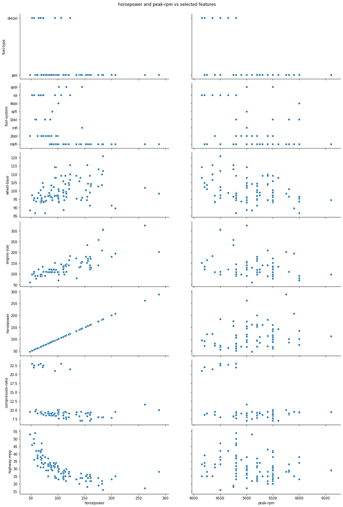

```python
g = sns.pairplot(automobile_df,
                 x_vars=['horsepower', 'peak-rpm'],
                 y_vars=col_list)
g.fig.set_figheight(20)
g.fig.set_figwidth(15)
g.fig.suptitle("horsepower and peak-rpm vs selected features", y=1.02)
```

```python
corr_list = show_correlation('horsepower')
corr_list
```

```
horsepower           1.000000
engine-size          0.810773
price                0.810533
curb-weight          0.751034
num-of-cylinders     0.691633
width                0.642482
bore                 0.576398
length               0.555003
wheel-base           0.352297
normalized-losses    0.203434
peak-rpm             0.130971
stroke               0.090170
symboling            0.071622
height              -0.110711
num-of-doors        -0.128837
compression-ratio   -0.205874
highway-mpg         -0.770908
city-mpg            -0.803620
Name: horsepower, dtype: float64
```

#### Looks like, horsepower has a strong correlation with engine-size, so I will predict missing values using linear regression

```python
X = automobile_df[automobile_df['horsepower'].notnull()][['engine-size']]
Y = automobile_df['horsepower'].dropna()
```

```python
from sklearn.linear_model import LinearRegression
from sklearn.model_selection import train_test_split


def impute_lin_regression(X,Y, df, X_col_name, Y_col_name):
    X_train, X_test, y_train, y_test = train_test_split(X, Y, test_size=0.4, random_state=101)

    lm = LinearRegression()
    lm.fit(X_train,y_train)
    predictions = lm.predict(df[[X_col_name]])

    fig = go.Figure()
    fig.add_trace(go.Scatter(x=df[X_col_name], y=predictions, mode='lines', name='predicted'))
    fig.add_trace(go.Scatter(x=df[X_col_name], y=df[Y_col_name], mode='markers', name='actual'))
    fig.update_layout(xaxis_title=X_col_name, yaxis_title=Y_col_name, title="Actual Data vs Linear Regression")
    fig.show()

    return lm
```

```python
lm = impute_lin_regression(X=X,Y=Y, df=automobile_df, X_col_name='engine-size', Y_col_name='horsepower')
```

[interactive chart not shown]

```python
# Selecting Engine Size where Horsepower is NaN
engine_size = list(automobile_df[automobile_df['horsepower'].isnull()]['engine-size'])
engine_size
```

```
[132, 132]
```

```python
index_list = automobile_df[automobile_df['horsepower'].isnull()]['engine-size'].index.values.tolist()
index_list
```

```
[130, 131]
```

```python
for i in range(0, len(engine_size)):
    predicted_hp = lm.predict([[ engine_size[i] ]])
    print(predicted_hp[0])
    automobile_df.loc[ index_list[i], ['horsepower']] = predicted_hp[0]
```

```
108.05514349408587
108.05514349408587
```

```python
# Just to double check
automobile_df.loc[index_list]
```

|  | symboling | normalized-losses | make | fuel-type | aspiration | num-of-doors | body-style | drive-wheels | engine-location | wheel-base | ... | engine-size | fuel-system | bore | stroke | compression-ratio | horsepower | peak-rpm | city-mpg | highway-mpg | price |
| --- | --- | --- | --- | --- | --- | --- | --- | --- | --- | --- | --- | --- | --- | --- | --- | --- | --- | --- | --- | --- | --- |
| 130 | 0 | 122.0 | renault | gas | std | 4.0 | wagon | fwd | front | 96.1 | ... | 132 | mpfi | 3.46 | 3.9 | 8.7 | 108.055143 | NaN | 23 | 31 | 9295.0 |
| 131 | 2 | 122.0 | renault | gas | std | 2.0 | hatchback | fwd | front | 96.1 | ... | 132 | mpfi | 3.46 | 3.9 | 8.7 | 108.055143 | NaN | 23 | 31 | 9895.0 |

2 rows × 26 columns

### peak-rpm

```python
corr_list = show_correlation('peak-rpm')
corr_list
```

```
peak-rpm             1.000000
symboling            0.274573
normalized-losses    0.237748
horsepower           0.130971
highway-mpg         -0.054257
stroke              -0.068288
price               -0.101649
city-mpg            -0.113788
num-of-cylinders    -0.124434
width               -0.219957
num-of-doors        -0.241521
engine-size         -0.244618
bore                -0.255053
curb-weight         -0.266306
length              -0.287325
height              -0.322272
wheel-base          -0.361052
compression-ratio   -0.436221
Name: peak-rpm, dtype: float64
```

#### No clear correlation so I will replace NaN with mean

```python
automobile_df[automobile_df['peak-rpm'].isnull()]
```

|  | symboling | normalized-losses | make | fuel-type | aspiration | num-of-doors | body-style | drive-wheels | engine-location | wheel-base | ... | engine-size | fuel-system | bore | stroke | compression-ratio | horsepower | peak-rpm | city-mpg | highway-mpg | price |
| --- | --- | --- | --- | --- | --- | --- | --- | --- | --- | --- | --- | --- | --- | --- | --- | --- | --- | --- | --- | --- | --- |
| 130 | 0 | 122.0 | renault | gas | std | 4.0 | wagon | fwd | front | 96.1 | ... | 132 | mpfi | 3.46 | 3.9 | 8.7 | 108.055143 | NaN | 23 | 31 | 9295.0 |
| 131 | 2 | 122.0 | renault | gas | std | 2.0 | hatchback | fwd | front | 96.1 | ... | 132 | mpfi | 3.46 | 3.9 | 8.7 | 108.055143 | NaN | 23 | 31 | 9895.0 |

2 rows × 26 columns

```python
peak_rpm_mean = automobile_df['peak-rpm'].mean()
peak_rpm_mean
```

```
5125.369458128079
```

```python
automobile_df['peak-rpm'].fillna(peak_rpm_mean, inplace=True)
```

### Price

```python
automobile_df[automobile_df['price'].isnull()]
```

|  | symboling | normalized-losses | make | fuel-type | aspiration | num-of-doors | body-style | drive-wheels | engine-location | wheel-base | ... | engine-size | fuel-system | bore | stroke | compression-ratio | horsepower | peak-rpm | city-mpg | highway-mpg | price |
| --- | --- | --- | --- | --- | --- | --- | --- | --- | --- | --- | --- | --- | --- | --- | --- | --- | --- | --- | --- | --- | --- |
| 9 | 0 | 122.0 | audi | gas | turbo | 2.0 | hatchback | 4wd | front | 99.5 | ... | 131 | mpfi | 3.13 | 3.40 | 7.0 | 160.0 | 5500.0 | 16 | 22 | NaN |
| 44 | 1 | 122.0 | isuzu | gas | std | 2.0 | sedan | fwd | front | 94.5 | ... | 90 | 2bbl | 3.03 | 3.11 | 9.6 | 70.0 | 5400.0 | 38 | 43 | NaN |
| 45 | 0 | 122.0 | isuzu | gas | std | 4.0 | sedan | fwd | front | 94.5 | ... | 90 | 2bbl | 3.03 | 3.11 | 9.6 | 70.0 | 5400.0 | 38 | 43 | NaN |
| 129 | 1 | 122.0 | porsche | gas | std | 2.0 | hatchback | rwd | front | 98.4 | ... | 203 | mpfi | 3.94 | 3.11 | 10.0 | 288.0 | 5750.0 | 17 | 28 | NaN |

4 rows × 26 columns

```python
col_list = ['normalized-losses', 'fuel-type', 'fuel-system', 'engine-size', 'horsepower', 'peak-rpm', 'highway-mpg']
```

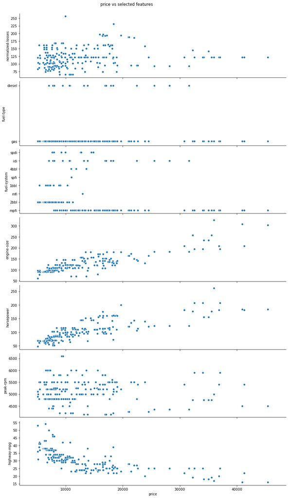

```python
g = sns.pairplot(automobile_df,
                 x_vars=['price'],
                 y_vars=col_list)
g.fig.set_figheight(20)
g.fig.set_figwidth(15)
g.fig.suptitle("price vs selected features", y=1.02)
```

```python
corr_list = show_correlation('price')
corr_list
```

```
price                1.000000
engine-size          0.872335
curb-weight          0.834415
horsepower           0.809052
width                0.751265
num-of-cylinders     0.708645
length               0.690628
wheel-base           0.584642
bore                 0.543155
height               0.135486
normalized-losses    0.133999
stroke               0.082269
compression-ratio    0.071107
num-of-doors         0.042435
symboling           -0.082391
peak-rpm            -0.101616
city-mpg            -0.686571
highway-mpg         -0.704692
Name: price, dtype: float64
```

#### Price has the strongest correlation with engine-size so I will fill missing values using linear regression

```python
X = automobile_df[automobile_df['price'].notnull()][['engine-size']]
Y = automobile_df['price'].dropna()
```

```python
lm = impute_lin_regression(X=X,Y=Y, df=automobile_df, X_col_name='engine-size', Y_col_name='price')
```

[interactive chart not shown]

```python
engine_size_list = list(automobile_df[automobile_df['price'].isnull()]['engine-size'])
engine_size_list
```

```
[131, 90, 90, 203]
```

```python
index_list = automobile_df[automobile_df['price'].isnull()]['engine-size'].index.values.tolist()
index_list
```

```
[9, 44, 45, 129]
```

```python
for i in range(0, len(engine_size_list)):
    predicted_price = lm.predict([[ engine_size_list[i] ]])
    print(predicted_price[0])
    automobile_df.loc[index_list[i], ['price']] = predicted_price[0]
```

```
13420.20211498028
7012.595456277933
7012.595456277933
24672.58454001855
```

```python
# Just to double check
automobile_df.loc[index_list]
```

|  | symboling | normalized-losses | make | fuel-type | aspiration | num-of-doors | body-style | drive-wheels | engine-location | wheel-base | ... | engine-size | fuel-system | bore | stroke | compression-ratio | horsepower | peak-rpm | city-mpg | highway-mpg | price |
| --- | --- | --- | --- | --- | --- | --- | --- | --- | --- | --- | --- | --- | --- | --- | --- | --- | --- | --- | --- | --- | --- |
| 9 | 0 | 122.0 | audi | gas | turbo | 2.0 | hatchback | 4wd | front | 99.5 | ... | 131 | mpfi | 3.13 | 3.40 | 7.0 | 160.0 | 5500.0 | 16 | 22 | 13420.202115 |
| 44 | 1 | 122.0 | isuzu | gas | std | 2.0 | sedan | fwd | front | 94.5 | ... | 90 | 2bbl | 3.03 | 3.11 | 9.6 | 70.0 | 5400.0 | 38 | 43 | 7012.595456 |
| 45 | 0 | 122.0 | isuzu | gas | std | 4.0 | sedan | fwd | front | 94.5 | ... | 90 | 2bbl | 3.03 | 3.11 | 9.6 | 70.0 | 5400.0 | 38 | 43 | 7012.595456 |
| 129 | 1 | 122.0 | porsche | gas | std | 2.0 | hatchback | rwd | front | 98.4 | ... | 203 | mpfi | 3.94 | 3.11 | 10.0 | 288.0 | 5750.0 | 17 | 28 | 24672.584540 |

4 rows × 26 columns

### Now let's look at the dataframe again to make sure there's no more NaN values

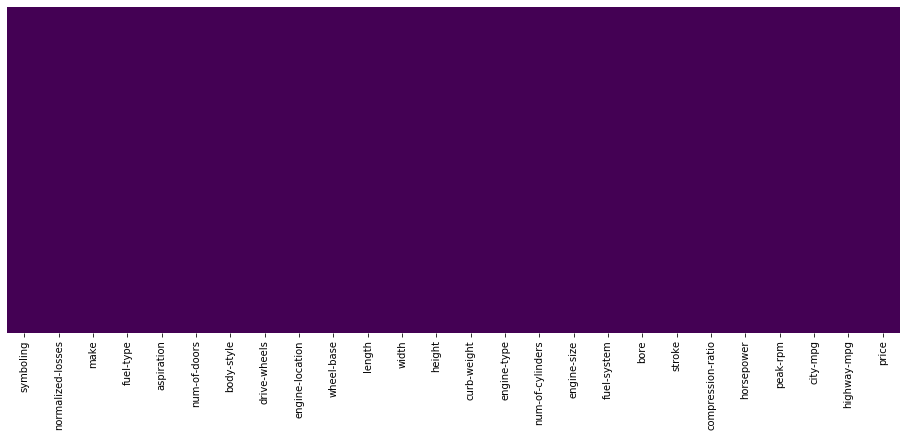

```python
fig, ax = plt.subplots(figsize=(16,6))
sns.heatmap(automobile_df.isnull(),yticklabels=False,cbar=False,cmap='viridis')
```

## Data Classification

### I want to use a classification algorithm to predict the number of cylinders of cars

### I will use Stratified Cross Validation to determine which supervised ML method yields the best score

#### Let's take a closer look at our target feature

```python
num_cyl_val_count = automobile_df['num-of-cylinders'].value_counts()
num_cyl_val_count
```

```
4.0     159
6.0      24
5.0      11
8.0       5
2.0       4
12.0      1
3.0       1
Name: num-of-cylinders, dtype: int64
```

#### For purpose of validation splits, num-of-cylinders values 3 and 12 are ineffective since only 1 instance of them are present in the dataset. So I'll just remove them.

```python
count = list(num_cyl_val_count.values)
num_of_cyl = list(num_cyl_val_count.index)

for i in range(0,len(num_of_cyl)):
    if count[i] < 3:
        automobile_df = automobile_df[automobile_df['num-of-cylinders'] != num_of_cyl[i]]
```

```python
automobile_df['num-of-cylinders'].value_counts()
```

```
4.0    159
6.0     24
5.0     11
8.0      5
2.0      4
Name: num-of-cylinders, dtype: int64
```

#### Dropping all features that I think non-related to num-of-cylinders or redundant

```python
drop_cols = ['aspiration', 'length', 'width', 'height', 'engine-location', 'symboling', 'normalized-losses',
             'make', 'num-of-doors', 'body-style', 'wheel-base', 'num-of-cylinders']
```

```python
trimmed_df = automobile_df.drop(drop_cols, axis=1)
trimmed_df
```

|  | fuel-type | drive-wheels | curb-weight | engine-type | engine-size | fuel-system | bore | stroke | compression-ratio | horsepower | peak-rpm | city-mpg | highway-mpg | price |
| --- | --- | --- | --- | --- | --- | --- | --- | --- | --- | --- | --- | --- | --- | --- |
| 0 | gas | rwd | 2548 | dohc | 130 | mpfi | 3.47 | 2.68 | 9.0 | 111.0 | 5000.0 | 21 | 27 | 13495.0 |
| 1 | gas | rwd | 2548 | dohc | 130 | mpfi | 3.47 | 2.68 | 9.0 | 111.0 | 5000.0 | 21 | 27 | 16500.0 |
| 2 | gas | rwd | 2823 | ohcv | 152 | mpfi | 2.68 | 3.47 | 9.0 | 154.0 | 5000.0 | 19 | 26 | 16500.0 |
| 3 | gas | fwd | 2337 | ohc | 109 | mpfi | 3.19 | 3.40 | 10.0 | 102.0 | 5500.0 | 24 | 30 | 13950.0 |
| 4 | gas | 4wd | 2824 | ohc | 136 | mpfi | 3.19 | 3.40 | 8.0 | 115.0 | 5500.0 | 18 | 22 | 17450.0 |
| ... | ... | ... | ... | ... | ... | ... | ... | ... | ... | ... | ... | ... | ... | ... |
| 200 | gas | rwd | 2952 | ohc | 141 | mpfi | 3.78 | 3.15 | 9.5 | 114.0 | 5400.0 | 23 | 28 | 16845.0 |
| 201 | gas | rwd | 3049 | ohc | 141 | mpfi | 3.78 | 3.15 | 8.7 | 160.0 | 5300.0 | 19 | 25 | 19045.0 |
| 202 | gas | rwd | 3012 | ohcv | 173 | mpfi | 3.58 | 2.87 | 8.8 | 134.0 | 5500.0 | 18 | 23 | 21485.0 |
| 203 | diesel | rwd | 3217 | ohc | 145 | idi | 3.01 | 3.40 | 23.0 | 106.0 | 4800.0 | 26 | 27 | 22470.0 |
| 204 | gas | rwd | 3062 | ohc | 141 | mpfi | 3.78 | 3.15 | 9.5 | 114.0 | 5400.0 | 19 | 25 | 22625.0 |

203 rows × 14 columns

#### Applying One-Hot-Coding on all nominal features

```python
non_num_cols = ['fuel-type', 'drive-wheels', 'engine-type', 'fuel-system']
```

```python
def make_dummy_col(df, non_num_cols):
    for col in non_num_cols:
        df_dummy = pd.get_dummies(df[col])
        df.drop(columns=[col], axis=1, inplace=True)
        df = pd.concat([df, df_dummy], axis=1)
        df_dummy = pd.DataFrame()
    return df
```

```python
trimmed_df = make_dummy_col(df=trimmed_df, non_num_cols=non_num_cols)
```

```python
trimmed_df.head(5)
```

|  | curb-weight | engine-size | bore | stroke | compression-ratio | horsepower | peak-rpm | city-mpg | highway-mpg | price | ... | ohcv | rotor | 1bbl | 2bbl | 4bbl | idi | mfi | mpfi | spdi | spfi |
| --- | --- | --- | --- | --- | --- | --- | --- | --- | --- | --- | --- | --- | --- | --- | --- | --- | --- | --- | --- | --- | --- |
| 0 | 2548 | 130 | 3.47 | 2.68 | 9.0 | 111.0 | 5000.0 | 21 | 27 | 13495.0 | ... | 0 | 0 | 0 | 0 | 0 | 0 | 0 | 1 | 0 | 0 |
| 1 | 2548 | 130 | 3.47 | 2.68 | 9.0 | 111.0 | 5000.0 | 21 | 27 | 16500.0 | ... | 0 | 0 | 0 | 0 | 0 | 0 | 0 | 1 | 0 | 0 |
| 2 | 2823 | 152 | 2.68 | 3.47 | 9.0 | 154.0 | 5000.0 | 19 | 26 | 16500.0 | ... | 1 | 0 | 0 | 0 | 0 | 0 | 0 | 1 | 0 | 0 |
| 3 | 2337 | 109 | 3.19 | 3.40 | 10.0 | 102.0 | 5500.0 | 24 | 30 | 13950.0 | ... | 0 | 0 | 0 | 0 | 0 | 0 | 0 | 1 | 0 | 0 |
| 4 | 2824 | 136 | 3.19 | 3.40 | 8.0 | 115.0 | 5500.0 | 18 | 22 | 17450.0 | ... | 0 | 0 | 0 | 0 | 0 | 0 | 0 | 1 | 0 | 0 |

5 rows × 30 columns

```python
from sklearn.model_selection import StratifiedKFold, KFold, cross_val_score
```

```python
strat_kf = StratifiedKFold(n_splits = 3, shuffle = True, random_state = 2)
```

#### I am creating a generic function to apply all the classification methods and get prediction score

#### I will also apply GridSearchCV to fine tune these methods

```python
from sklearn.model_selection import GridSearchCV

def get_prediction_score(clf, param_grid, X_train, X_test, y_train, y_test):
    grid = GridSearchCV(clf, param_grid, refit=True, verbose=2)
    grid.fit(X_train,y_train)
    return grid.score(X_test, y_test), grid.best_estimator_
```

```python
knn_param_grid = {  'n_neighbors': list(range(1,31)), 'weights': ["uniform", "distance"]  }
SVC_param_grid = { 'C': [0.1,1, 10, 100, 1000], 'gamma': [1,0.1,0.01,0.001], 'kernel':['rbf']  }
rfc_param_grid = {  'n_estimators': list(range(1,30))  }
```

#### I am making a dictionary with some known supervised ML methods used for classification

```python
from sklearn.neighbors import KNeighborsClassifier
from sklearn.svm import SVC
from sklearn.ensemble import RandomForestClassifier

scores_knn, scores_svc, scores_rfc = np.array([]), np.array([]), np.array([])

classifier_dict = {
    'knn': {
        'name': 'K-Nearest Neighbors',
        'clf_model': KNeighborsClassifier(),
        'param_grid': knn_param_grid,
        'scores_arr': scores_knn,
        'mean_score': 0,
        'best_params': None
    },

    'svc': {
        'name': 'Support Vector Machine',
        'clf_model': SVC(),
        'param_grid': SVC_param_grid,
        'scores_arr': scores_svc,
        'mean_score': 0,
        'best_params': None
    },

    'rfc': {
        'name': 'Random Forest Classifier',
        'clf_model': RandomForestClassifier(),
        'param_grid': rfc_param_grid,
        'scores_arr': scores_rfc,
        'mean_score': 0,
        'best_params': None
    },

}
```

```python
for train_index, test_index in strat_kf.split(trimmed_df, automobile_df['num-of-cylinders']):

    X_train = trimmed_df.iloc[train_index]
    X_test = trimmed_df.iloc[test_index]
    y_train = automobile_df.iloc[train_index]['num-of-cylinders']
    y_test = automobile_df.iloc[test_index]['num-of-cylinders']

    for clf in classifier_dict:
        clf_model = classifier_dict[clf]['clf_model']
        param_grid = classifier_dict[clf]['param_grid']
        scores_arr = classifier_dict[clf]['scores_arr']

        scores_i, best_est = get_prediction_score(clf_model, param_grid, X_train, X_test, y_train, y_test)

        scores_arr = np.append(scores_arr, scores_i)
        classifier_dict[clf]['best_params'] = best_est
        classifier_dict[clf]['scores_arr'] = scores_arr
```

[output not shown]

[output cut: 19 more lines]

[output not shown]

[output not shown]

[output not shown]

[output cut: 507 more lines]

[output not shown]

[output not shown]

[output not shown]

[output cut: 111 more lines]

[output not shown]

[output not shown]

[output not shown]

[output cut: 244 more lines]

[output not shown]

[output not shown]

[output not shown]

[output cut: 561 more lines]

[output not shown]

[output not shown]

[output not shown]

[output cut: 139 more lines]

[output not shown]

[output not shown]

[output not shown]

[output cut: 248 more lines]

[output not shown]

[output not shown]

[output not shown]

[output cut: 536 more lines]

[output not shown]

[output not shown]

[output not shown]

[output cut: 164 more lines]

[output not shown]

[output not shown]

[output not shown]

[output cut: 200 more lines]

[output not shown]

```
[Parallel(n_jobs=1)]: Done 145 out of 145 | elapsed:    3.8s finished
```

```python
for clf in classifier_dict:
    classifier_dict[clf]['mean_score'] = classifier_dict[clf]['scores_arr'].mean()
```

```python
best_clf_key = max(classifier_dict.items(), key=lambda x: x[1]['mean_score'])[0]
```

```python
print('---------------------------------------------------SUMMARY---------------------------------------------------\n\n')

for clf in classifier_dict:
    print( f"{classifier_dict[clf]['name']}: \n" )
    print( f"Mean score: {classifier_dict[clf]['mean_score']}: \n" )
    print( f"Best parameters from grid search: \n\n{classifier_dict[clf]['best_params']}: \n\n" )
    print("---------------------------------------------------------------------------------------------------------\n\n")
```

```
---------------------------------------------------SUMMARY---------------------------------------------------


K-Nearest Neighbors:

Mean score: 0.8325285338015803:

Best parameters from grid search:

KNeighborsClassifier(algorithm='auto', leaf_size=30, metric='minkowski',
                     metric_params=None, n_jobs=None, n_neighbors=13, p=2,
                     weights='uniform'):


---------------------------------------------------------------------------------------------------------


Support Vector Machine:

Mean score: 0.783289435177056:

Best parameters from grid search:

SVC(C=0.1, break_ties=False, cache_size=200, class_weight=None, coef0=0.0,
    decision_function_shape='ovr', degree=3, gamma=1, kernel='rbf', max_iter=-1,
    probability=False, random_state=None, shrinking=True, tol=0.001,
    verbose=False):


---------------------------------------------------------------------------------------------------------


Random Forest Classifier:

Mean score: 0.9656131109160082:

Best parameters from grid search:

RandomForestClassifier(bootstrap=True, ccp_alpha=0.0, class_weight=None,
                       criterion='gini', max_depth=None, max_features='auto',
                       max_leaf_nodes=None, max_samples=None,
                       min_impurity_decrease=0.0, min_impurity_split=None,
                       min_samples_leaf=1, min_samples_split=2,
                       min_weight_fraction_leaf=0.0, n_estimators=24,
                       n_jobs=None, oob_score=False, random_state=None,
                       verbose=0, warm_start=False):


---------------------------------------------------------------------------------------------------------
```

```python
md("<h2> Classification algorithm with the best prediction score is:<h2> <h1>{}<h1>".format(classifier_dict[best_clf_key]['name']))
```

Classification algorithm with the best prediction score is: Random Forest Classifier